# Risk Factor Analysis

## Outcome Variable

**Outcome Variable:** haz

## Predictor Variables

**Intervention Variable:** perdiar6

**Adjustment Set:**

- arm
- sex
- W_mage
- meducyrs
- feducyrs
- hhwealth_quart
- hfoodsec
- W_mhtcm
- W_mwtkg
- W_mbmi
- W_birthwt
- W_birthlen
- W_nrooms
- month
- brthmon
- impfloor
- impsan
- safeh20
- delta_W_mage
- delta_meducyrs
- delta_feducyrs
- delta_hhwealth_quart
- delta_hfoodsec
- delta_W_mhtcm
- delta_W_mwtkg
- delta_W_mbmi
- delta_W_birthwt
- delta_W_birthlen
- delta_W_nrooms
- delta_month
- delta_brthmon
- delta_impfloor
- delta_impsan
- delta_safeh20

## Stratifying Variables

The analysis was stratified on these variable(s):

- agecat
- studyid
- country

## Data Summary

| agecat | studyid | country | perdiar6 | n_cell | n |
| --- | --- | --- | --- | --- | --- |
| Birth | CMIN | BANGLADESH | 0% | 16 | 26 |
| Birth | CMIN | BANGLADESH | (0%, 5%] | 4 | 26 |
| Birth | CMIN | BANGLADESH | >5% | 6 | 26 |
| Birth | CONTENT | PERU | 0% | 0 | 2 |
| Birth | CONTENT | PERU | (0%, 5%] | 1 | 2 |
| Birth | CONTENT | PERU | >5% | 1 | 2 |
| Birth | EE | PAKISTAN | 0% | 223 | 240 |
| Birth | EE | PAKISTAN | (0%, 5%] | 15 | 240 |
| Birth | EE | PAKISTAN | >5% | 2 | 240 |
| Birth | MAL-ED | BANGLADESH | 0% | 72 | 231 |
| Birth | MAL-ED | BANGLADESH | (0%, 5%] | 90 | 231 |
| Birth | MAL-ED | BANGLADESH | >5% | 69 | 231 |
| Birth | MAL-ED | BRAZIL | 0% | 57 | 65 |
| Birth | MAL-ED | BRAZIL | (0%, 5%] | 6 | 65 |
| Birth | MAL-ED | BRAZIL | >5% | 2 | 65 |
| Birth | MAL-ED | INDIA | 0% | 12 | 47 |
| Birth | MAL-ED | INDIA | (0%, 5%] | 24 | 47 |
| Birth | MAL-ED | INDIA | >5% | 11 | 47 |
| Birth | MAL-ED | NEPAL | 0% | 8 | 27 |
| Birth | MAL-ED | NEPAL | (0%, 5%] | 10 | 27 |
| Birth | MAL-ED | NEPAL | >5% | 9 | 27 |
| Birth | MAL-ED | PERU | 0% | 67 | 233 |
| Birth | MAL-ED | PERU | (0%, 5%] | 72 | 233 |
| Birth | MAL-ED | PERU | >5% | 94 | 233 |
| Birth | MAL-ED | SOUTH AFRICA | 0% | 86 | 113 |
| Birth | MAL-ED | SOUTH AFRICA | (0%, 5%] | 23 | 113 |
| Birth | MAL-ED | SOUTH AFRICA | >5% | 4 | 113 |
| Birth | MAL-ED | TANZANIA, UNITED REPUBLIC OF | 0% | 59 | 125 |
| Birth | MAL-ED | TANZANIA, UNITED REPUBLIC OF | (0%, 5%] | 45 | 125 |
| Birth | MAL-ED | TANZANIA, UNITED REPUBLIC OF | >5% | 21 | 125 |

[output cut: 87 more lines]

The following strata were considered:

- agecat: 24 months, studyid: CMIN, country: BANGLADESH
- agecat: 24 months, studyid: CONTENT, country: PERU
- agecat: 24 months, studyid: EE, country: PAKISTAN
- agecat: 24 months, studyid: MAL-ED, country: BANGLADESH
- agecat: 24 months, studyid: MAL-ED, country: BRAZIL
- agecat: 24 months, studyid: MAL-ED, country: INDIA
- agecat: 24 months, studyid: MAL-ED, country: NEPAL
- agecat: 24 months, studyid: MAL-ED, country: PERU
- agecat: 24 months, studyid: MAL-ED, country: SOUTH AFRICA
- agecat: 24 months, studyid: MAL-ED, country: TANZANIA, UNITED REPUBLIC OF
- agecat: 24 months, studyid: NIH-Birth, country: BANGLADESH
- agecat: 24 months, studyid: NIH-Crypto, country: BANGLADESH
- agecat: 24 months, studyid: PROVIDE, country: BANGLADESH
- agecat: 6 months, studyid: CMIN, country: BANGLADESH
- agecat: 6 months, studyid: CONTENT, country: PERU
- agecat: 6 months, studyid: EE, country: PAKISTAN
- agecat: 6 months, studyid: MAL-ED, country: BANGLADESH
- agecat: 6 months, studyid: MAL-ED, country: BRAZIL
- agecat: 6 months, studyid: MAL-ED, country: INDIA
- agecat: 6 months, studyid: MAL-ED, country: NEPAL
- agecat: 6 months, studyid: MAL-ED, country: PERU
- agecat: 6 months, studyid: MAL-ED, country: SOUTH AFRICA
- agecat: 6 months, studyid: MAL-ED, country: TANZANIA, UNITED REPUBLIC OF
- agecat: 6 months, studyid: NIH-Birth, country: BANGLADESH
- agecat: 6 months, studyid: NIH-Crypto, country: BANGLADESH
- agecat: 6 months, studyid: PROVIDE, country: BANGLADESH
- agecat: Birth, studyid: CMIN, country: BANGLADESH
- agecat: Birth, studyid: CONTENT, country: PERU
- agecat: Birth, studyid: EE, country: PAKISTAN
- agecat: Birth, studyid: MAL-ED, country: BANGLADESH
- agecat: Birth, studyid: MAL-ED, country: BRAZIL
- agecat: Birth, studyid: MAL-ED, country: INDIA
- agecat: Birth, studyid: MAL-ED, country: NEPAL
- agecat: Birth, studyid: MAL-ED, country: PERU
- agecat: Birth, studyid: MAL-ED, country: SOUTH AFRICA
- agecat: Birth, studyid: MAL-ED, country: TANZANIA, UNITED REPUBLIC OF
- agecat: Birth, studyid: NIH-Birth, country: BANGLADESH
- agecat: Birth, studyid: NIH-Crypto, country: BANGLADESH
- agecat: Birth, studyid: PROVIDE, country: BANGLADESH

### Dropped Strata

Some strata were dropped due to rare outcomes:

- agecat: Birth, studyid: CMIN, country: BANGLADESH
- agecat: Birth, studyid: CONTENT, country: PERU
- agecat: Birth, studyid: EE, country: PAKISTAN
- agecat: Birth, studyid: MAL-ED, country: BRAZIL
- agecat: Birth, studyid: MAL-ED, country: SOUTH AFRICA
- agecat: 6 months, studyid: EE, country: PAKISTAN
- agecat: 6 months, studyid: MAL-ED, country: BRAZIL
- agecat: 24 months, studyid: EE, country: PAKISTAN
- agecat: 24 months, studyid: MAL-ED, country: BRAZIL

## Methods Detail

We’re interested in the causal parameters $E[Y_a]$ for all values of $a \in \mathcal{A}$. These parameters represent the mean outcome if, possibly contrary to fact, we intervened to set all units to have $A=a$. Under the randomization and positivity assumptions, these are identified by the statistical parameters $\psi_a=E_W[E_{Y|A,W}(Y|A=a,W)]$. In addition, we’re interested in the mean of $Y$, $E[Y]$ under no intervention (the observed mean). We will estimate these parameters by using SuperLearner to fit the relevant likelihood factors – $E_{Y|A,W}(Y|A=a,W)$ and $p(A=a|W)$, and then updating our likelihood fit using a joint TMLE.

For unadjusted analyses ($W=\{\}$), initial likelihoods were estimated using Lrnr_glm to estimate the simple $E(Y|A)$ and Lrnr_mean to estimate $p(A)$. For adjusted analyses, a small library containing Lrnr_glmnet, Lrnr_xgboost, and Lrnr_mean was used.

Having estimated these parameters, we will then use the delta method to estimate relative risks and attributable risks relative to a prespecified baseline level of $A$.

# Results Detail

## Results Plots

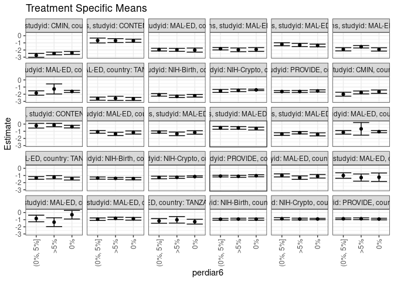

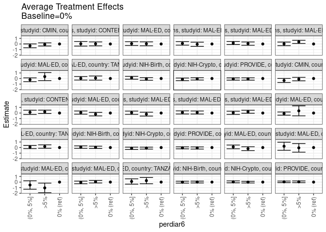

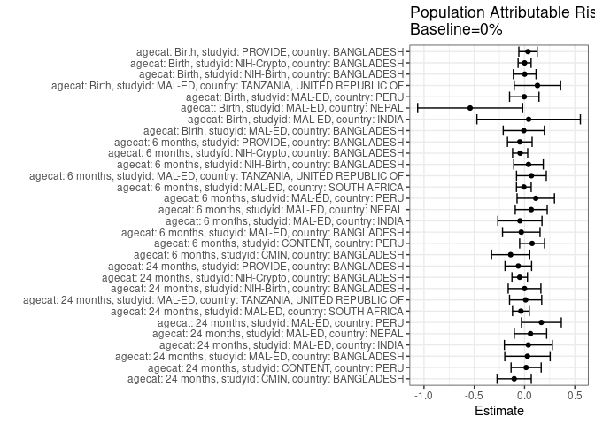

## Results Table

### Parameter: TSM

| agecat | studyid | country | intervention_level | baseline_level | estimate | ci_lower | ci_upper |
| --- | --- | --- | --- | --- | --- | --- | --- |
| Birth | MAL-ED | BANGLADESH | 0% | NA | -1.1105554 | -1.3604555 | -0.8606553 |
| Birth | MAL-ED | BANGLADESH | (0%, 5%] | NA | -0.9931905 | -1.2089537 | -0.7774274 |
| Birth | MAL-ED | BANGLADESH | >5% | NA | -1.3071947 | -1.5468991 | -1.0674903 |
| Birth | MAL-ED | INDIA | 0% | NA | -1.2445144 | -1.8328854 | -0.6561435 |
| Birth | MAL-ED | INDIA | (0%, 5%] | NA | -1.0115618 | -1.3951389 | -0.6279847 |
| Birth | MAL-ED | INDIA | >5% | NA | -1.2955761 | -1.7966782 | -0.7944739 |
| Birth | MAL-ED | NEPAL | 0% | NA | -0.3125000 | -0.9090602 | 0.2840602 |
| Birth | MAL-ED | NEPAL | (0%, 5%] | NA | -0.8360000 | -1.2964736 | -0.3755264 |
| Birth | MAL-ED | NEPAL | >5% | NA | -1.3533333 | -1.9688465 | -0.7378201 |
| Birth | MAL-ED | PERU | 0% | NA | -0.8800745 | -1.0656875 | -0.6944614 |
| Birth | MAL-ED | PERU | (0%, 5%] | NA | -0.9374581 | -1.1160802 | -0.7588360 |
| Birth | MAL-ED | PERU | >5% | NA | -0.8164380 | -0.9789415 | -0.6539345 |
| Birth | MAL-ED | TANZANIA, UNITED REPUBLIC OF | 0% | NA | -1.2837930 | -1.6193656 | -0.9482205 |
| Birth | MAL-ED | TANZANIA, UNITED REPUBLIC OF | (0%, 5%] | NA | -1.1729730 | -1.5059904 | -0.8399555 |
| Birth | MAL-ED | TANZANIA, UNITED REPUBLIC OF | >5% | NA | -1.0254279 | -1.4778854 | -0.5729705 |
| Birth | NIH-Birth | BANGLADESH | 0% | NA | -0.9329681 | -1.0753590 | -0.7905772 |
| Birth | NIH-Birth | BANGLADESH | (0%, 5%] | NA | -0.9428144 | -1.0696460 | -0.8159828 |
| Birth | NIH-Birth | BANGLADESH | >5% | NA | -0.9229333 | -1.0451823 | -0.8006843 |
| Birth | NIH-Crypto | BANGLADESH | 0% | NA | -0.9100134 | -1.0064648 | -0.8135619 |
| Birth | NIH-Crypto | BANGLADESH | (0%, 5%] | NA | -0.8762383 | -1.0288966 | -0.7235800 |
| Birth | NIH-Crypto | BANGLADESH | >5% | NA | -0.9189433 | -1.0438101 | -0.7940766 |
| Birth | PROVIDE | BANGLADESH | 0% | NA | -0.9195233 | -1.0329625 | -0.8060841 |
| Birth | PROVIDE | BANGLADESH | (0%, 5%] | NA | -0.8766777 | -0.9833102 | -0.7700452 |
| Birth | PROVIDE | BANGLADESH | >5% | NA | -0.8722426 | -0.9945609 | -0.7499242 |
| 6 months | CMIN | BANGLADESH | 0% | NA | -1.6461742 | -1.8834184 | -1.4089299 |
| 6 months | CMIN | BANGLADESH | (0%, 5%] | NA | -1.9965383 | -2.2671931 | -1.7258835 |
| 6 months | CMIN | BANGLADESH | >5% | NA | -1.7523521 | -1.9534640 | -1.5512402 |
| 6 months | CONTENT | PERU | 0% | NA | -0.3535898 | -0.5325176 | -0.1746620 |
| 6 months | CONTENT | PERU | (0%, 5%] | NA | -0.2210649 | -0.5512276 | 0.1090978 |
| 6 months | CONTENT | PERU | >5% | NA | -0.1313354 | -0.3692912 | 0.1066203 |

[output cut: 60 more lines]

### Parameter: E(Y)

| agecat | studyid | country | intervention_level | baseline_level | estimate | ci_lower | ci_upper |
| --- | --- | --- | --- | --- | --- | --- | --- |
| Birth | MAL-ED | BANGLADESH | NA | NA | -1.1180952 | -1.2525408 | -0.9836496 |
| Birth | MAL-ED | INDIA | NA | NA | -1.2036170 | -1.4976814 | -0.9095527 |
| Birth | MAL-ED | NEPAL | NA | NA | -0.8533333 | -1.2104864 | -0.4961803 |
| Birth | MAL-ED | PERU | NA | NA | -0.8827897 | -1.0001058 | -0.7654736 |
| Birth | MAL-ED | TANZANIA, UNITED REPUBLIC OF | NA | NA | -1.1556000 | -1.3655361 | -0.9456639 |
| Birth | NIH-Birth | BANGLADESH | NA | NA | -0.9314050 | -1.0202164 | -0.8425936 |
| Birth | NIH-Crypto | BANGLADESH | NA | NA | -0.9094945 | -0.9809370 | -0.8380521 |
| Birth | PROVIDE | BANGLADESH | NA | NA | -0.8851020 | -0.9601332 | -0.8100709 |
| 6 months | CMIN | BANGLADESH | NA | NA | -1.7844376 | -1.9222926 | -1.6465825 |
| 6 months | CONTENT | PERU | NA | NA | -0.2785256 | -0.4098735 | -0.1471776 |
| 6 months | MAL-ED | BANGLADESH | NA | NA | -1.2049931 | -1.3222136 | -1.0877726 |
| 6 months | MAL-ED | INDIA | NA | NA | -1.2115254 | -1.3298727 | -1.0931782 |
| 6 months | MAL-ED | NEPAL | NA | NA | -0.5615819 | -0.6741832 | -0.4489807 |
| 6 months | MAL-ED | PERU | NA | NA | -1.3236661 | -1.4316775 | -1.2156546 |
| 6 months | MAL-ED | SOUTH AFRICA | NA | NA | -1.0633202 | -1.1909180 | -0.9357224 |
| 6 months | MAL-ED | TANZANIA, UNITED REPUBLIC OF | NA | NA | -1.3687449 | -1.4907629 | -1.2467270 |
| 6 months | NIH-Birth | BANGLADESH | NA | NA | -1.4073821 | -1.4960598 | -1.3187043 |
| 6 months | NIH-Crypto | BANGLADESH | NA | NA | -1.1986783 | -1.2700937 | -1.1272630 |
| 6 months | PROVIDE | BANGLADESH | NA | NA | -1.0916915 | -1.1661176 | -1.0172654 |
| 24 months | CMIN | BANGLADESH | NA | NA | -2.5109504 | -2.6361514 | -2.3857494 |
| 24 months | CONTENT | PERU | NA | NA | -0.6868598 | -0.8388476 | -0.5348719 |
| 24 months | MAL-ED | BANGLADESH | NA | NA | -1.9783962 | -2.1050210 | -1.8517715 |
| 24 months | MAL-ED | INDIA | NA | NA | -1.8861894 | -2.0110006 | -1.7613783 |
| 24 months | MAL-ED | NEPAL | NA | NA | -1.3075877 | -1.4270718 | -1.1881037 |
| 24 months | MAL-ED | PERU | NA | NA | -1.7524710 | -1.8736426 | -1.6312994 |
| 24 months | MAL-ED | SOUTH AFRICA | NA | NA | -1.6450595 | -1.7797240 | -1.5103950 |
| 24 months | MAL-ED | TANZANIA, UNITED REPUBLIC OF | NA | NA | -2.6455607 | -2.7807256 | -2.5103959 |
| 24 months | NIH-Birth | BANGLADESH | NA | NA | -2.2190579 | -2.3217459 | -2.1163699 |
| 24 months | NIH-Crypto | BANGLADESH | NA | NA | -1.4412646 | -1.5249156 | -1.3576135 |
| 24 months | PROVIDE | BANGLADESH | NA | NA | -1.6024221 | -1.6857420 | -1.5191023 |

### Parameter: ATE

| agecat | studyid | country | intervention_level | baseline_level | estimate | ci_lower | ci_upper |
| --- | --- | --- | --- | --- | --- | --- | --- |
| Birth | MAL-ED | BANGLADESH | 0% | 0% | 0.0000000 | 0.0000000 | 0.0000000 |
| Birth | MAL-ED | BANGLADESH | (0%, 5%] | 0% | 0.1173648 | -0.2129139 | 0.4476436 |
| Birth | MAL-ED | BANGLADESH | >5% | 0% | -0.1966393 | -0.5432424 | 0.1499637 |
| Birth | MAL-ED | INDIA | 0% | 0% | 0.0000000 | 0.0000000 | 0.0000000 |
| Birth | MAL-ED | INDIA | (0%, 5%] | 0% | 0.2329526 | -0.4881848 | 0.9540900 |
| Birth | MAL-ED | INDIA | >5% | 0% | -0.0510616 | -0.8206839 | 0.7185607 |
| Birth | MAL-ED | NEPAL | 0% | 0% | 0.0000000 | 0.0000000 | 0.0000000 |
| Birth | MAL-ED | NEPAL | (0%, 5%] | 0% | -0.5235000 | -1.2771047 | 0.2301047 |
| Birth | MAL-ED | NEPAL | >5% | 0% | -1.0408333 | -1.8980034 | -0.1836633 |
| Birth | MAL-ED | PERU | 0% | 0% | 0.0000000 | 0.0000000 | 0.0000000 |
| Birth | MAL-ED | PERU | (0%, 5%] | 0% | -0.0573836 | -0.2969346 | 0.1821674 |
| Birth | MAL-ED | PERU | >5% | 0% | 0.0636365 | -0.1608858 | 0.2881588 |
| Birth | MAL-ED | TANZANIA, UNITED REPUBLIC OF | 0% | 0% | 0.0000000 | 0.0000000 | 0.0000000 |
| Birth | MAL-ED | TANZANIA, UNITED REPUBLIC OF | (0%, 5%] | 0% | 0.1108200 | -0.3650298 | 0.5866699 |
| Birth | MAL-ED | TANZANIA, UNITED REPUBLIC OF | >5% | 0% | 0.2583651 | -0.3017629 | 0.8184931 |
| Birth | NIH-Birth | BANGLADESH | 0% | 0% | 0.0000000 | 0.0000000 | 0.0000000 |
| Birth | NIH-Birth | BANGLADESH | (0%, 5%] | 0% | -0.0098463 | -0.1837322 | 0.1640395 |
| Birth | NIH-Birth | BANGLADESH | >5% | 0% | 0.0100348 | -0.1580674 | 0.1781371 |
| Birth | NIH-Crypto | BANGLADESH | 0% | 0% | 0.0000000 | 0.0000000 | 0.0000000 |
| Birth | NIH-Crypto | BANGLADESH | (0%, 5%] | 0% | 0.0337750 | -0.1401906 | 0.2077406 |
| Birth | NIH-Crypto | BANGLADESH | >5% | 0% | -0.0089300 | -0.1593944 | 0.1415345 |
| Birth | PROVIDE | BANGLADESH | 0% | 0% | 0.0000000 | 0.0000000 | 0.0000000 |
| Birth | PROVIDE | BANGLADESH | (0%, 5%] | 0% | 0.0428456 | -0.1000431 | 0.1857342 |
| Birth | PROVIDE | BANGLADESH | >5% | 0% | 0.0472807 | -0.1063961 | 0.2009575 |
| 6 months | CMIN | BANGLADESH | 0% | 0% | 0.0000000 | 0.0000000 | 0.0000000 |
| 6 months | CMIN | BANGLADESH | (0%, 5%] | 0% | -0.3503641 | -0.7111806 | 0.0104523 |
| 6 months | CMIN | BANGLADESH | >5% | 0% | -0.1061779 | -0.4180233 | 0.2056674 |
| 6 months | CONTENT | PERU | 0% | 0% | 0.0000000 | 0.0000000 | 0.0000000 |
| 6 months | CONTENT | PERU | (0%, 5%] | 0% | 0.1325250 | -0.2436721 | 0.5087220 |
| 6 months | CONTENT | PERU | >5% | 0% | 0.2222544 | -0.0759899 | 0.5204986 |

[output cut: 60 more lines]

### Parameter: PAR

| agecat | studyid | country | intervention_level | baseline_level | estimate | ci_lower | ci_upper |
| --- | --- | --- | --- | --- | --- | --- | --- |
| Birth | MAL-ED | BANGLADESH | 0% | NA | -0.0075399 | -0.2120888 | 0.1970091 |
| Birth | MAL-ED | INDIA | 0% | NA | 0.0408974 | -0.4735654 | 0.5553602 |
| Birth | MAL-ED | NEPAL | 0% | NA | -0.5408333 | -1.0628947 | -0.0187719 |
| Birth | MAL-ED | PERU | 0% | NA | -0.0027152 | -0.1491211 | 0.1436907 |
| Birth | MAL-ED | TANZANIA, UNITED REPUBLIC OF | 0% | NA | 0.1281930 | -0.1023974 | 0.3587835 |
| Birth | NIH-Birth | BANGLADESH | 0% | NA | 0.0015631 | -0.1112015 | 0.1143277 |
| Birth | NIH-Crypto | BANGLADESH | 0% | NA | 0.0005188 | -0.0640665 | 0.0651041 |
| Birth | PROVIDE | BANGLADESH | 0% | NA | 0.0344212 | -0.0568397 | 0.1256822 |
| 6 months | CMIN | BANGLADESH | 0% | NA | -0.1382634 | -0.3281325 | 0.0516057 |
| 6 months | CONTENT | PERU | 0% | NA | 0.0750642 | -0.0487540 | 0.1988824 |
| 6 months | MAL-ED | BANGLADESH | 0% | NA | -0.0324950 | -0.2191440 | 0.1541541 |
| 6 months | MAL-ED | INDIA | 0% | NA | -0.0460398 | -0.2655669 | 0.1734873 |
| 6 months | MAL-ED | NEPAL | 0% | NA | 0.0664885 | -0.0924831 | 0.2254600 |
| 6 months | MAL-ED | PERU | 0% | NA | 0.1115431 | -0.0743715 | 0.2974576 |
| 6 months | MAL-ED | SOUTH AFRICA | 0% | NA | -0.0071009 | -0.0803127 | 0.0661109 |
| 6 months | MAL-ED | TANZANIA, UNITED REPUBLIC OF | 0% | NA | 0.0682727 | -0.0797755 | 0.2163208 |
| 6 months | NIH-Birth | BANGLADESH | 0% | NA | 0.0394264 | -0.1073737 | 0.1862265 |
| 6 months | NIH-Crypto | BANGLADESH | 0% | NA | -0.0439133 | -0.1190315 | 0.0312048 |
| 6 months | PROVIDE | BANGLADESH | 0% | NA | -0.0472678 | -0.1698127 | 0.0752772 |
| 24 months | CMIN | BANGLADESH | 0% | NA | -0.1031973 | -0.2732782 | 0.0668837 |
| 24 months | CONTENT | PERU | 0% | NA | 0.0156930 | -0.1341183 | 0.1655044 |
| 24 months | MAL-ED | BANGLADESH | 0% | NA | 0.0291361 | -0.1965327 | 0.2548050 |
| 24 months | MAL-ED | INDIA | 0% | NA | 0.0378052 | -0.2005363 | 0.2761467 |
| 24 months | MAL-ED | NEPAL | 0% | NA | 0.0589775 | -0.1017668 | 0.2197218 |
| 24 months | MAL-ED | PERU | 0% | NA | 0.1675566 | -0.0305706 | 0.3656837 |
| 24 months | MAL-ED | SOUTH AFRICA | 0% | NA | -0.0363213 | -0.1197270 | 0.0470845 |
| 24 months | MAL-ED | TANZANIA, UNITED REPUBLIC OF | 0% | NA | 0.0107591 | -0.1492931 | 0.1708113 |
| 24 months | NIH-Birth | BANGLADESH | 0% | NA | 0.0000085 | -0.1626623 | 0.1626792 |
| 24 months | NIH-Crypto | BANGLADESH | 0% | NA | -0.0481086 | -0.1251376 | 0.0289204 |
| 24 months | PROVIDE | BANGLADESH | 0% | NA | -0.0619757 | -0.1942594 | 0.0703081 |